# 5291

## Step1. Import data

```r
library(readxl)
data<-read_xlsx("NHANES Dataset Smoking.xlsx")
#View(data)
colnames(data)
```

```
##  [1] "Case"     "SEQN"     "SDPPSU6"  "SDPSTRA6" "WTPFHX6"  "HSAGEIR"
##  [7] "HSSEX"    "DMARACER" "BMPWTLBS" "BMPHTIN"  "PEPMNK1R" "PEPMNK5R"
## [13] "HAR1"     "HAR3"     "SMOKE"    "TCP"      "HBP"
```

The National Health and Nutrition Survey (NHANES3.DAT) contains 17030 observations and 16 variables. (delete)SDPPSU6: Pseudo-PSU: 1, 2. (delete)SDPSTRA6: Pseudo-stratum: 01-49 (delete)WTPFHX6: Statistical weight: 225.93-139744.9 HSAGEIR: Age: years HSSEX: Sex: 0=Female, 1=Male DMARACER: Race: 1=White, 2=Black, 3=Other. BMPWTLBS: Body Weight: pounds BMPHTIN: Standing Height: inches (delete)PEPMNK1R: Average Systolic BP: mm Hg PEPMNK5R: Average Diastolic BP: mm Hg (delete)HAR1: Has repondent smoked > 100 cigarettes in life: 1=Yes, 2=No (delete)HAR3: Does respondent smoke cigarettes now: 1=Yes, 2=No SMOKE: Smoking: 1=if HAR1=2, 2=if HAR1=1&HAR3=2, 3=if HAR1=1&HAR3=1 TCP: Serum Cholesterol: mg/100 ml HBP: High Blood Pressure: 0 if PEPMNK1R <=140, 1 if PEPMNK1R > 140

```r
data<-data[-dim(data)[1],]
data<-data[,-c(1,2,3,4,13,14)]
data<-na.omit(data)
#View(data)
```

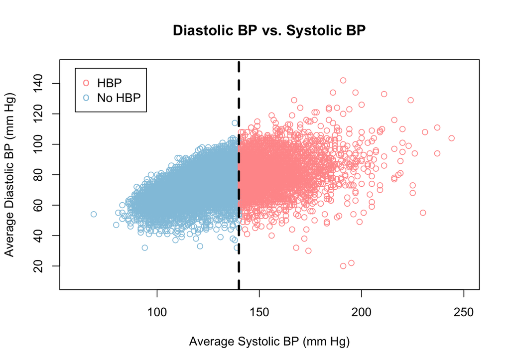

```r
#png("fig/SBP-DBP.png",width = 480, height = 400, units = "px")
plot(data[data$HBP==0,]$PEPMNK1R, data[data$HBP==0,]$PEPMNK5R,col = "#92C5DE" ,xlim=c(60,250), ylim=c(10,150),xlab='Average Systolic BP (mm Hg)', ylab='Average Diastolic BP (mm Hg)', main='Diastolic BP vs. Systolic BP')
points(data[data$HBP==1,]$PEPMNK1R, data[data$HBP==1,]$PEPMNK5R,col = "#FF9999")
abline(v=140, lwd=3, lty=2)
legend(60,150,legend=c("HBP","No HBP"), col=c("#FF9999","#92C5DE"), pch=c("o","o"), ncol=1)
```

```r
#dev.off()
```

## EDA

```r
print(cor(data$PEPMNK1R, data$PEPMNK5R))
```

```
## [1] 0.4970324
```

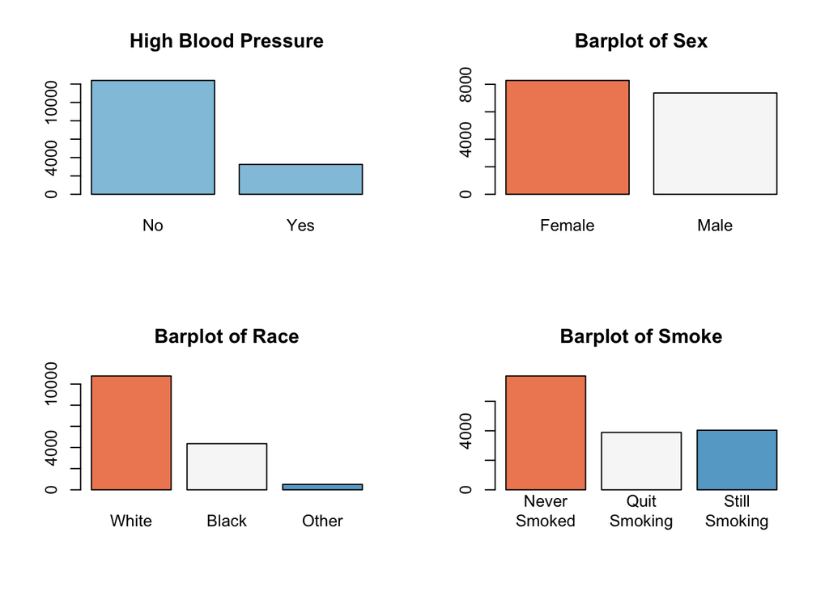

```r
library(RColorBrewer)
par(mfrow=c(2,2))
barplot(table(data$HBP), main = "High Blood Pressure", names.arg = c("No","Yes"), col = "#92C5DE")
barplot(table(data$HSSEX), main="Barplot of Sex", names.arg = c("Female","Male"),col = brewer.pal(n = 2, name = "RdBu"))
barplot(table(data$DMARACER), main="Barplot of Race",names.arg = c("White","Black","Other"),col = brewer.pal(n = 3, name = "RdBu"))
barplot(table(data$SMOKE), main="Barplot of Smoke", names.arg = gsub("\\s","\n",c("Never Smoked","Quit Smoking","Still Smoking")),col = brewer.pal(n = 3, name = "RdBu"))
```

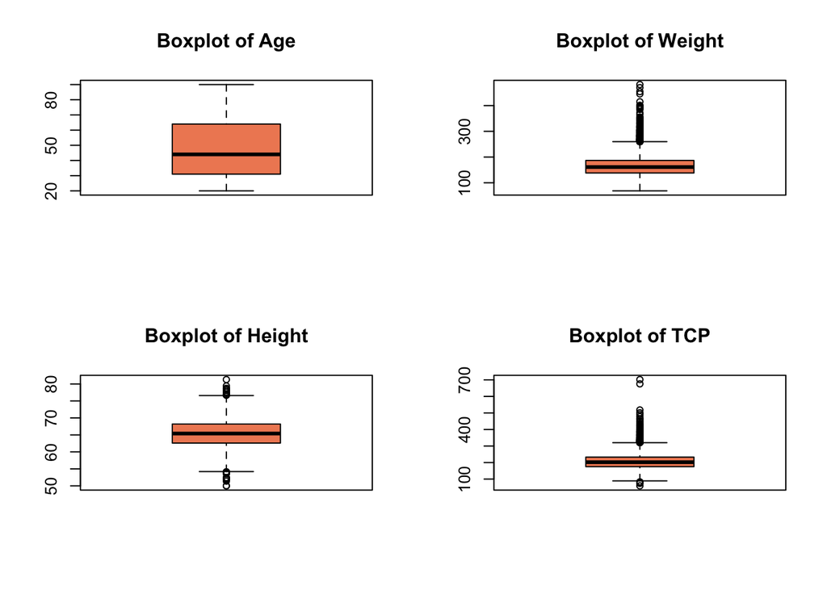

```r
#barplot(table(data$SMOKE), main="Barplot of Smoke", names.arg = c("Quit Smoking","Still Smoking"),col = brewer.pal(n = 2, name = "RdBu"))

par(mfrow=c(2,2))
boxplot(data$HSAGEIR, main="Boxplot of Age",col = brewer.pal(n = 2, name = "RdBu"))
boxplot(data$BMPWTLBS, main="Boxplot of Weight",col = brewer.pal(n = 2, name = "RdBu"))
boxplot(data$BMPHTIN, main="Boxplot of Height",col = brewer.pal(n = 2, name = "RdBu"))
boxplot(data$TCP, main="Boxplot of TCP",col = brewer.pal(n = 2, name = "RdBu"))
```

```r
HBP<-data$HBP
age<-data$HSAGEIR
sex<-as.factor(data$HSSEX)
race<-as.factor(data$DMARACER)
smoke<-as.factor(data$SMOKE)
weight<-data$BMPWTLBS
height<-data$BMPHTIN
chole<-data$TCP
```

## Model Selection

### 1. Full model without interaction

```r
fit<-glm(HBP~age+sex+race+weight+height+smoke+chole,family=binomial("logit"))
summary(fit)
```

```
##
## Call:
## glm(formula = HBP ~ age + sex + race + weight + height + smoke +
##     chole, family = binomial("logit"))
##
## Deviance Residuals:
##     Min       1Q   Median       3Q      Max
## -1.9896  -0.5754  -0.2922  -0.1542   3.0675
##
## Coefficients:
##               Estimate Std. Error z value Pr(>|z|)
## (Intercept) -4.4418336  0.5813797  -7.640 2.17e-14 ***
## age          0.0780812  0.0016232  48.102  < 2e-16 ***
## sex1         0.1737441  0.0670370   2.592  0.00955 **
## race2        0.4835721  0.0555090   8.712  < 2e-16 ***
## race3        0.1465102  0.1509113   0.971  0.33163
## weight       0.0081776  0.0006794  12.037  < 2e-16 ***
## height      -0.0587319  0.0092344  -6.360 2.02e-10 ***
## smoke2      -0.0381432  0.0566037  -0.674  0.50040
## smoke3       0.1835219  0.0633730   2.896  0.00378 **
## chole        0.0045838  0.0005171   8.864  < 2e-16 ***
## ---
## Signif. codes:  0 '***' 0.001 '**' 0.01 '*' 0.05 '.' 0.1 ' ' 1
##
## (Dispersion parameter for binomial family taken to be 1)
##
##     Null deviance: 15986  on 15642  degrees of freedom
## Residual deviance: 11679  on 15633  degrees of freedom
## AIC: 11699
##
## Number of Fisher Scoring iterations: 6
```

### 2. Test whether race and smoke are significant

```r
fit1<-glm(HBP~age+sex+weight+height+chole,family=binomial("logit"))
anova(fit1,fit)
```

```
## Analysis of Deviance Table
##
## Model 1: HBP ~ age + sex + weight + height + chole
## Model 2: HBP ~ age + sex + race + weight + height + smoke + chole
##   Resid. Df Resid. Dev Df Deviance
## 1     15637      11774
## 2     15633      11679  4   94.974
```

```r
qchisq(0.95,4)
```

```
## [1] 9.487729
```

** Reject the null and keep the fit model. **

## test whether smoke is significant

```r
fit1<-glm(HBP~age+sex+race+weight+height+chole,family=binomial("logit"))
anova(fit1,fit)
```

```
## Analysis of Deviance Table
##
## Model 1: HBP ~ age + sex + race + weight + height + chole
## Model 2: HBP ~ age + sex + race + weight + height + smoke + chole
##   Resid. Df Resid. Dev Df Deviance
## 1     15635      11691
## 2     15633      11679  2   11.902
```

```r
qchisq(0.95,2)
```

```
## [1] 5.991465
```

## reject the null and keep the fit model.

## test whether race is significant

```r
fit1<-glm(HBP~age+sex+weight+height+smoke+chole,family=binomial("logit"))
anova(fit1,fit)
```

```
## Analysis of Deviance Table
##
## Model 1: HBP ~ age + sex + weight + height + smoke + chole
## Model 2: HBP ~ age + sex + race + weight + height + smoke + chole
##   Resid. Df Resid. Dev Df Deviance
## 1     15635      11755
## 2     15633      11679  2   75.492
```

```r
qchisq(0.95,2)
```

```
## [1] 5.991465
```

## now consider the interaction term.

```r
fit<-glm(HBP~age+sex+race+weight+height+smoke+chole+sex*race+sex*smoke+race*smoke,family=binomial("logit"))
summary(fit)
```

```
##
## Call:
## glm(formula = HBP ~ age + sex + race + weight + height + smoke +
##     chole + sex * race + sex * smoke + race * smoke, family = binomial("logit"))
##
## Deviance Residuals:
##     Min       1Q   Median       3Q      Max
## -1.9956  -0.5749  -0.2917  -0.1516   3.0789
##
## Coefficients:
##                Estimate Std. Error z value Pr(>|z|)
## (Intercept)  -4.3762017  0.5824078  -7.514 5.74e-14 ***
## age           0.0779613  0.0016311  47.798  < 2e-16 ***
## sex1          0.0501026  0.0943123   0.531 0.595252
## race2         0.3404484  0.0884845   3.848 0.000119 ***
## race3        -0.0965934  0.2517327  -0.384 0.701190
## weight        0.0083673  0.0006833  12.245  < 2e-16 ***
## height       -0.0590798  0.0092490  -6.388 1.68e-10 ***
## smoke2       -0.0156875  0.0875186  -0.179 0.857743
## smoke3       -0.1001834  0.1041062  -0.962 0.335889
## chole         0.0045839  0.0005184   8.843  < 2e-16 ***
## sex1:race2    0.1039460  0.1137605   0.914 0.360860
## sex1:race3    0.6025829  0.3210768   1.877 0.060551 .
## sex1:smoke2   0.0246958  0.1147389   0.215 0.829584
## sex1:smoke3   0.2871965  0.1272637   2.257 0.024027 *
## race2:smoke2 -0.0251271  0.1366345  -0.184 0.854092
## race3:smoke2 -0.4887987  0.4006976  -1.220 0.222514
## race2:smoke3  0.3557780  0.1335980   2.663 0.007744 **
## race3:smoke3  0.1321877  0.3679235   0.359 0.719385
## ---
## Signif. codes:  0 '***' 0.001 '**' 0.01 '*' 0.05 '.' 0.1 ' ' 1
##
## (Dispersion parameter for binomial family taken to be 1)
##
##     Null deviance: 15986  on 15642  degrees of freedom
## Residual deviance: 11657  on 15625  degrees of freedom
## AIC: 11693
##
## Number of Fisher Scoring iterations: 6
```

## test whether interactions between sex and smoke, race and smoke are significant

```r
fit1<-glm(HBP~age+sex+race+weight+height+smoke+chole+sex*smoke+race*smoke,family=binomial("logit"))
anova(fit1,fit)
```

```
## Analysis of Deviance Table
##
## Model 1: HBP ~ age + sex + race + weight + height + smoke + chole + sex *
##     smoke + race * smoke
## Model 2: HBP ~ age + sex + race + weight + height + smoke + chole + sex *
##     race + sex * smoke + race * smoke
##   Resid. Df Resid. Dev Df Deviance
## 1     15627      11661
## 2     15625      11657  2   4.0804
```

```r
qchisq(0.95,2)
```

```
## [1] 5.991465
```

## don’t reject the null and choose fit1.

## test whether interaction between sex and smoke is significant

```r
fit2<-glm(HBP~age+sex+race+weight+height+smoke+chole+race * smoke,family=binomial("logit"))
anova(fit2,fit1)
```

```
## Analysis of Deviance Table
##
## Model 1: HBP ~ age + sex + race + weight + height + smoke + chole + race *
##     smoke
## Model 2: HBP ~ age + sex + race + weight + height + smoke + chole + sex *
##     smoke + race * smoke
##   Resid. Df Resid. Dev Df Deviance
## 1     15629      11668
## 2     15627      11661  2   6.6562
```

```r
qchisq(0.95,2)
```

```
## [1] 5.991465
```

## reject the null, so the interaction between sex and smoke is significant. Now test race and smoke

```r
fit2<-glm(HBP~age+sex+race+weight+height+smoke+chole+sex * smoke,family=binomial("logit"))
anova(fit2,fit1)
```

```
## Analysis of Deviance Table
##
## Model 1: HBP ~ age + sex + race + weight + height + smoke + chole + sex *
##     smoke
## Model 2: HBP ~ age + sex + race + weight + height + smoke + chole + sex *
##     smoke + race * smoke
##   Resid. Df Resid. Dev Df Deviance
## 1     15631      11673
## 2     15627      11661  4   11.419
```

```r
qchisq(0.95,4)
```

```
## [1] 9.487729
```

#reject the null, so the interaction between race and smoke is significant.

```r
fit0<-glm(HBP~age+sex+race+weight+height+smoke+chole,family=binomial("logit"))
fit_33<-glm(HBP~age+sex+race+weight+height+smoke+chole+sex*smoke,family=binomial("logit"))
anova(fit0,fit_33)
```

```
## Analysis of Deviance Table
##
## Model 1: HBP ~ age + sex + race + weight + height + smoke + chole
## Model 2: HBP ~ age + sex + race + weight + height + smoke + chole + sex *
##     smoke
##   Resid. Df Resid. Dev Df Deviance
## 1     15633      11679
## 2     15631      11673  2   6.6504
```

```r
qchisq(0.95,2)
```

```
## [1] 5.991465
```

```r
fit_34<-glm(HBP~age+sex+race+weight+height+smoke+chole+sex*smoke+race*sex,family=binomial("logit"))
anova(fit_33,fit_34)
```

```
## Analysis of Deviance Table
##
## Model 1: HBP ~ age + sex + race + weight + height + smoke + chole + sex *
##     smoke
## Model 2: HBP ~ age + sex + race + weight + height + smoke + chole + sex *
##     smoke + race * sex
##   Resid. Df Resid. Dev Df Deviance
## 1     15631      11673
## 2     15629      11668  2   4.5845
```

Both sex*smoke, race*smoke significant.

```r
fit_ex = glm(HBP~age+sex+race+weight+height+smoke+chole+height*weight,family=binomial("logit"))
anova(fit0,fit_ex)
```

```
## Analysis of Deviance Table
##
## Model 1: HBP ~ age + sex + race + weight + height + smoke + chole
## Model 2: HBP ~ age + sex + race + weight + height + smoke + chole + height *
##     weight
##   Resid. Df Resid. Dev Df Deviance
## 1     15633      11679
## 2     15632      11674  1   4.7384
```

```r
qchisq(0.95,1)
```

```
## [1] 3.841459
```

```r
f1<-ifelse(data$HSSEX==0&data$SMOKE==1,1,0)
f2<-ifelse(data$HSSEX==0&data$SMOKE==2,1,0)
f3<-ifelse(data$HSSEX==0&data$SMOKE==3,1,0)
m1<-ifelse(data$HSSEX==1&data$SMOKE==1,1,0)
m2<-ifelse(data$HSSEX==1&data$SMOKE==2,1,0)
m3<-ifelse(data$HSSEX==1&data$SMOKE==3,1,0)
```

```r
fit<-glm(HBP~age+race+weight+height+chole+f2+f3+m1+m2+m3,family=binomial("logit"))
summary(fit)
```

```
##
## Call:
## glm(formula = HBP ~ age + race + weight + height + chole + f2 +
##     f3 + m1 + m2 + m3, family = binomial("logit"))
##
## Deviance Residuals:
##     Min       1Q   Median       3Q      Max
## -1.9811  -0.5741  -0.2917  -0.1537   3.0838
##
## Coefficients:
##               Estimate Std. Error z value Pr(>|z|)
## (Intercept) -4.4523053  0.5815652  -7.656 1.92e-14 ***
## age          0.0780870  0.0016272  47.989  < 2e-16 ***
## race2        0.4811374  0.0555287   8.665  < 2e-16 ***
## race3        0.1452297  0.1509288   0.962    0.336
## weight       0.0082010  0.0006799  12.062  < 2e-16 ***
## height      -0.0581213  0.0092406  -6.290 3.18e-10 ***
## chole        0.0045484  0.0005175   8.789  < 2e-16 ***
## f2          -0.0176154  0.0816010  -0.216    0.829
## f3           0.0259669  0.0901753   0.288    0.773
## m1           0.0943963  0.0884317   1.067    0.286
## m2           0.0859963  0.0820336   1.048    0.294
## m3           0.4221859  0.0913172   4.623 3.78e-06 ***
## ---
## Signif. codes:  0 '***' 0.001 '**' 0.01 '*' 0.05 '.' 0.1 ' ' 1
##
## (Dispersion parameter for binomial family taken to be 1)
##
##     Null deviance: 15986  on 15642  degrees of freedom
## Residual deviance: 11673  on 15631  degrees of freedom
## AIC: 11697
##
## Number of Fisher Scoring iterations: 6
```

## test whether they are significant

```r
fit1<-glm(HBP~age+race+weight+height+chole,family=binomial("logit"))
anova(fit1,fit)
```

```
## Analysis of Deviance Table
##
## Model 1: HBP ~ age + race + weight + height + chole
## Model 2: HBP ~ age + race + weight + height + chole + f2 + f3 + m1 + m2 +
##     m3
##   Resid. Df Resid. Dev Df Deviance
## 1     15636      11698
## 2     15631      11673  5   25.762
```

```r
qchisq(0.95,5)
```

```
## [1] 11.0705
```

## reject the null and choose the below model as our final model.

```r
summary(fit)
```

```
##
## Call:
## glm(formula = HBP ~ age + race + weight + height + chole + f2 +
##     f3 + m1 + m2 + m3, family = binomial("logit"))
##
## Deviance Residuals:
##     Min       1Q   Median       3Q      Max
## -1.9811  -0.5741  -0.2917  -0.1537   3.0838
##
## Coefficients:
##               Estimate Std. Error z value Pr(>|z|)
## (Intercept) -4.4523053  0.5815652  -7.656 1.92e-14 ***
## age          0.0780870  0.0016272  47.989  < 2e-16 ***
## race2        0.4811374  0.0555287   8.665  < 2e-16 ***
## race3        0.1452297  0.1509288   0.962    0.336
## weight       0.0082010  0.0006799  12.062  < 2e-16 ***
## height      -0.0581213  0.0092406  -6.290 3.18e-10 ***
## chole        0.0045484  0.0005175   8.789  < 2e-16 ***
## f2          -0.0176154  0.0816010  -0.216    0.829
## f3           0.0259669  0.0901753   0.288    0.773
## m1           0.0943963  0.0884317   1.067    0.286
## m2           0.0859963  0.0820336   1.048    0.294
## m3           0.4221859  0.0913172   4.623 3.78e-06 ***
## ---
## Signif. codes:  0 '***' 0.001 '**' 0.01 '*' 0.05 '.' 0.1 ' ' 1
##
## (Dispersion parameter for binomial family taken to be 1)
##
##     Null deviance: 15986  on 15642  degrees of freedom
## Residual deviance: 11673  on 15631  degrees of freedom
## AIC: 11697
##
## Number of Fisher Scoring iterations: 6
```